# Case Study 3: Basic model fitting: Leaf burning

Richard Wilkinson

## The data

An experiment to determine the effect on the burn time of leaves on the concentration of Nitrogen, Chlorine and Potassium. To build a purely scientific model from first principles based on chemistry and physics alone, would be extremely challenging. So instead, we propose various statistical models and fit them to the observations.

```r
filepath <- "https://www.maths.nottingham.ac.uk/personal/pmzrdw/LeafData.txt"
# Download the data from the internet
download.file(filepath, destfile = "LeafData.txt", method = "curl")
LeafData <- read.table(file='LeafData.txt', header=TRUE)
LeafData[1:10,]
```

```
##    Nitrogen Chlorine Potassium log_burn_time
## 1      3.05     1.45      5.67          0.34
## 2      4.22     1.35      4.86          0.11
## 3      3.34     0.26      4.19          0.38
## 4      3.77     0.23      4.42          0.68
## 5      3.52     1.10      3.17          0.18
## 6      3.54     0.76      2.76          0.00
## 7      3.74     1.59      3.81          0.08
## 8      3.78     0.39      3.23          0.11
## 9      2.92     0.39      5.44          1.53
## 10     3.10     0.64      6.16          0.77
```

```r
str(LeafData) # look at the data structure
```

```
## 'data.frame':    30 obs. of  4 variables:
##  $ Nitrogen     : num  3.05 4.22 3.34 3.77 3.52 3.54 3.74 3.78 2.92 3.1 ...
##  $ Chlorine     : num  1.45 1.35 0.26 0.23 1.1 0.76 1.59 0.39 0.39 0.64 ...
##  $ Potassium    : num  5.67 4.86 4.19 4.42 3.17 2.76 3.81 3.23 5.44 6.16 ...
##  $ log_burn_time: num  0.34 0.11 0.38 0.68 0.18 0 0.08 0.11 1.53 0.77 ...
```

The variables are

- Nitrogen %
- Chlorine %
- Potassium %
- log of leaf burn time

Lets start (as always), by visualising the data.

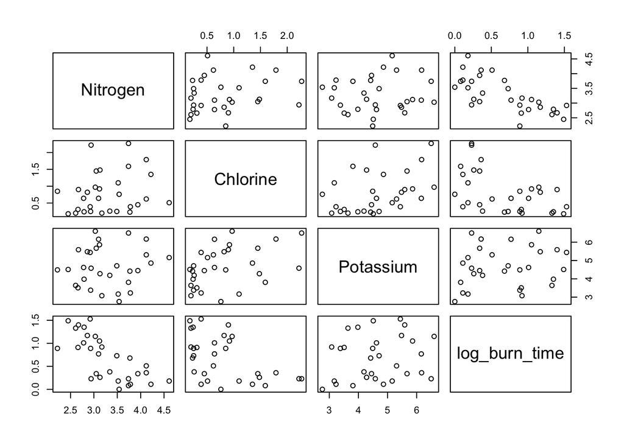

```r
plot(LeafData)
```

If you choose not to use R markdown, then you will have to manually save all of your figures using a command such as

```r
dev.print(pdf, file="FuelScatterPlots.pdf", width=12, height=12) # save the file
```

What questions might we want to ask?

- How does the percentage of nitrogen, chlorine and potassium affect the leaf burn time?
- Which percentage is most important?

## Possible models

For the $i$th observation let $y_i$ be the log of leaf burn time, $x_{i,1}$ be the Nitrogen %, $x_{i,2}$ be the Chlorine %, and $x_{i,3}$ be the Potassium %. Let $\beta=(a,b,c)^T$.

Which of the following are linear models?

- $y_i=b x_{i,1}+\epsilon_i$,
- $y_i=a+b x_{i,1}+\epsilon_i$,
- $y_i=b^3 x_{i,1} + c x_{i,2}+\epsilon_i$,
- $y_i=a+b (x_{i,1}-x_{i,2})^2+\epsilon_i$,
- $y_i=a+2b x_{i,1}+c\log(x_{i,2})+\epsilon_i$.
- $y_i=a x_{i,1}+ b x_{i,1}^2 +\epsilon_i$.

What is the design matrix $Z$ and parameter vector $\beta$ in the cases that are linear models?

## Simple linear regression

Let $y$ be the log leaf burn time and $x$ be the Nitrogen %. We can write our simple linear regression model as $y_i=a+b x_i+\epsilon_i,\qquad i=1,\dots,30.$

What are $\beta$, $g(x)^T$ and $Z$ here?

To find the sum of squares estimates for this model using R, we can do the following:

```r
fit1 <- lm(log_burn_time~Nitrogen, data = LeafData)
fit1
```

```
##
## Call:
## lm(formula = log_burn_time ~ Nitrogen, data = LeafData)
##
## Coefficients:
## (Intercept)     Nitrogen
##      2.6257      -0.5916
```

```r
coef(fit1)  # explicitly gives the fitted coefficients
```

```
## (Intercept)    Nitrogen
##   2.6257040  -0.5916137
```

```r
deviance(fit1)
```

```
## [1] 3.243512
```

Let $D_1$ denote the deviance of this first order linear fit.

## Model Choice

We can fit a quadratic model. $y_{i}=a +{b} x_i+c x_i^2+\epsilon_i\qquad i=1,\dots,n.$

The vector of parameters is $\beta=(a, b, c)^T$,

$z_i^T = [1~x_i~x_i^2]$ and the design matrix is $Z=\begin{bmatrix} 1 & x_1 & x_1^2 \\ 1 & x_2 & x_2^2 \\ \vdots & \vdots & \vdots \\ 1 & x_n & x_n^2 \end{bmatrix}$

NB: This is a linear model since it is linear in the *parameters*.

```r
fit2 <- lm(log_burn_time~Nitrogen+I(Nitrogen^2), data =LeafData)
fit2
```

```
##
## Call:
## lm(formula = log_burn_time ~ Nitrogen + I(Nitrogen^2), data = LeafData)
##
## Coefficients:
##   (Intercept)       Nitrogen  I(Nitrogen^2)
##        4.6985        -1.8525         0.1861
```

```r
deviance(fit2)
```

```
## [1] 3.103197
```

Let $D_2$ denote the deviance of this quadratic linear model.

When $D_{1}-D_{2}$ is large then the quadratic model is much better than the simple linear regression, i.e. the straight line model is significantly improved by adding a quadratic term.

Note the use of

```r
I(Nitrogen^2)
```

in the model formula. This is needed to seperate the two terms Nitrogen and Nitrogen^2.

If we had used

```r
lm(formula = log_burn_time ~ Nitrogen + Nitrogen^2, data=LeafData)
```

then we would be fitting the linear model $y_{i}=a +{b} (x_i+ x_i^2)+\epsilon_i\qquad i=1,\dots,n.$ instead (try it!).

We can also fit the null model $y_{i}=a +\epsilon_i\qquad i=1,\dots,n.$

```r
fit0 <- lm(log_burn_time~1, data=LeafData)
fit0
```

```
##
## Call:
## lm(formula = log_burn_time ~ 1, data = LeafData)
##
## Coefficients:
## (Intercept)
##       0.686
```

```r
deviance(fit0)
```

```
## [1] 6.68952
```

We can plot these three models

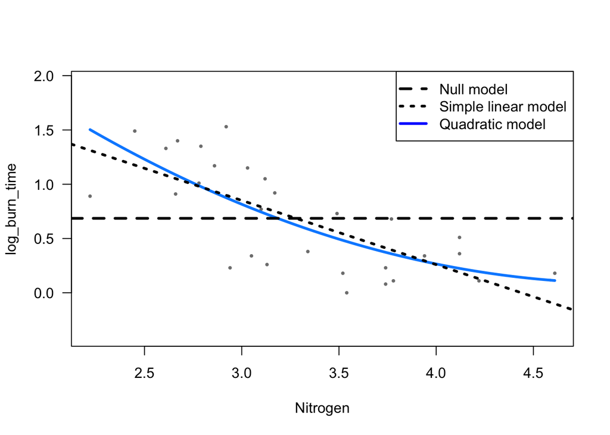

```r
library(visreg)
out = visreg(fit2, band=FALSE)
abline(fit1, lty=3, lwd=3)
abline(fit0, lty=2, lwd=3)
legend(x="topright",   lty = c(2, 3, 1), c("Null model", "Simple linear model", "Quadratic model"),  merge = TRUE, col=c(1,1,'blue'), lwd=3)
```

The plot and the deviances suggest that the linear model is probably sufficient. This is a subjective judgement based on eyeballing the data and fits - perhaps the most important aspect of model fitting. A more theoretical approach to model selection will be covered in Chapter 7.

## Simple linear model revisited, this time with matrices

Consider the simple linear model considered above. The design matrix is $Z =\begin{bmatrix} 1 & x_{1\,1} \\ 1 & x_{2\,1} \\ \vdots & \vdots \\ 1 & x_{30\ 1} & \end{bmatrix}.$ We know that:

- The unbiased least squares estimator is

$\hat{\beta}=(Z^TZ)^{-1}Z^Ty=(2.63,-0.59)^T$

- An unbiased estimator for $\sigma^2$ is

$s^2=\frac{1}{n-p}(y-Z\hat{\beta})^T(y-Z\hat{\beta})=0.12$

- An estimate for $\operatorname{Var}(\hat{\beta})$ is given by

$s^2(Z^TZ)^{-1}= \begin{bmatrix} 0.130 & -0.04\cr -0.04 & 0.012 \end{bmatrix}$

These quantities are all available from R:

```r
coef(fit1)
```

```
## (Intercept)    Nitrogen
##   2.6257040  -0.5916137
```

```r
fit1.sum <- summary(fit1)
fit1.sum$sigma^2
```

```
## [1] 0.1158397
```

```r
vcov(fit1)
```

```
##             (Intercept)   Nitrogen
## (Intercept)   0.1303385 -0.0385758
## Nitrogen     -0.0385758  0.0117657
```

The most useful R command for summarizing the model fit is

```r
summary(fit1)
```

```
##
## Call:
## lm(formula = log_burn_time ~ Nitrogen, data = LeafData)
##
## Residuals:
##      Min       1Q   Median       3Q      Max
## -0.65636 -0.27698  0.03712  0.27876  0.63181
##
## Coefficients:
##             Estimate Std. Error t value Pr(>|t|)
## (Intercept)   2.6257     0.3610   7.273 6.44e-08 ***
## Nitrogen     -0.5916     0.1085  -5.454 8.03e-06 ***
## ---
## Signif. codes:  0 '***' 0.001 '**' 0.01 '*' 0.05 '.' 0.1 ' ' 1
##
## Residual standard error: 0.3404 on 28 degrees of freedom
## Multiple R-squared:  0.5151, Adjusted R-squared:  0.4978
## F-statistic: 29.75 on 1 and 28 DF,  p-value: 8.025e-06
```

## R$^2$ and adjusted $R^2$

Above we fitted the model $y_i=a + b x_i+\epsilon_i$ and found that $s^2=0.12$ and $D=3.24$.

For the null model $y_i=a+\epsilon_i$ we find that $s^2(\textrm{null})=0.23$ and $D_0=6.69$.

Using R:

```r
fit1.sum <- summary(fit1)
fit1.sum$r.squared  ## gives the R^2 value
```

```
## [1] 0.5151353
```

```r
fit1.sum$adj.r.squared ## gives the adjusted R^2 value
```

```
## [1] 0.4978187
```

Next, define a new input variate $w$ to be 30 independent observations from a $U(0,1)$ distribution and fit the model $y=a+bx+c w+\epsilon.$

For this model we get that $R^2=0.516\qquad\text{and}\qquad R_{adj}^2=0.480.$

Notice that $R^2$ must improve when an input variate is added to the model. In this case, the input variate is unrelated to $y$ and so $R^2$ only improves by a very small amount. However $R_{adj}^2$ has gone down: it reflects the fact that this new input variate is not providing any useful information and is not worth including in the model.

This shows why the adjusted R-squared is useful.

## Confidence intervals using R

```r
confint(fit1)   # gives 95% CI for both parameters
```

```
##                 2.5 %     97.5 %
## (Intercept)  1.886179  3.3652287
## Nitrogen    -0.813804 -0.3694234
```

```r
confint(fit1, level=0.99)   # gives 99% CI for both parameters
```

```
##                  0.5 %     99.5 %
## (Intercept)  1.6280992  3.6233088
## Nitrogen    -0.8913442 -0.2918831
```

```r
confint(fit1, level=0.99, parm="Nitrogen")   ## supplies just the nitrogen CI.
```

```
##               0.5 %     99.5 %
## Nitrogen -0.8913442 -0.2918831
```